# A3: Incarceration

### Introduction

As the US has the highest number of prisoners, I want to explore more about how the total prison population has changed and grown as well as how many men and women correspond to this population.

dataset:Jail Population:“https://github.com/melaniewalsh/Neat-Datasets/blob/main/us-jail-pop.csv?raw=true”.  
Variables: total_jail_pop, female_jail_pop, male_jail_pop

To determine whether the overall jail/prison population in the US has increased or decreased over the past few years, I primarily use the “total_jail_pop” variable in the jail population dataset because this dataset has more adequate values to evaluate compared to the prison dataset. Additionally, I use “female_jail_pop” and “male_jail_pop” in the same dataset that represent the female and male jail populations in order to maintain consistency and also calculate the difference between the number of female and male prisoners.

### Summary Information

After analysis, I can see that the total number of prisoners in the US from 1970 to 2018 was about **23,207,908**, which is extremely high. **California** appeared to have the highest percentage of prisoners among the states in the US. The average male prison population is **2,108**, which is higher than the average female prison population of **208**. The prison population has decreased by **7.78%** over the past ten years, which is a sign that society is progressing.

### The Dataset

> Who collected the data?

Vera Institute of Justice collected this data

> How was the data collected or generated?

Data collected or generated by gathering data from Bureau of Justice Statistics (BJS) data collections: the Census of Jails (COJ) and the Annual Survey of Jails (ASJ). They analyze and merge and update data to produce this dataset

> Why was the data collected?

This data is gathered in order to support community justice. The community will be able to use and perform the analysis to identify any bias patterns from this data, and from there they will be able to use it to fight for justice and create a more equitable society. This data is working toward the goal of distributing the transparency and accessibility of the prison data for people.

> How many observations (rows) are in your data?

There are 153,811 observations

> How many features (columns) are in the data?

There are 28 columns in this data

> What, if any, ethical questions or questions of power do you need to consider when working with this data?

Does this dataset show any pattern about the unfairness for the minority group that include the discrimination of gender, races, age?

How is transparency safeguarded to avoid misconduct or misunderstanding?

> What are possible limitations or problems with this data?

In order to perform analysis, it is necessary to remove any incomplete or unrepresentative data from the dataset; however, doing so will likely remove a large number of values from the analysis, which could lead to bias and skewing of the results. increasing the chance that incorrect conclusions will be drawn and jeopardizing the data’s overall integrity.

### Trends Over Time Chart

To show the pattern of how the jail population has changed over time, I plot a line graph from 1970 to 2018 in the three states of WA, CA, and FL. Neglecting the fact that each state has a different level of jail population, I can see the common trend in these three lines that are shown in the plot. The number of people incarcerated rose dramatically between 1980 and 1990, then increased steadily until 2008 or 2009. It began to decline from that time until the most recent date, which is a sign that society is improving.

[output not shown]

[figure not shown]

### Variable Comparison Chart

I use a scatterplot to represent these two variables in order to visualize the relationship between the gender of prisoners, both male and female. The clusters that form a positive linear line on the plot show a positive relationship between the male and female populations. The fact that their correlation is positive indicates that they are interdependent. For instance, when the population of men increases, so does the number of women in jail, and vice versa.

[output not shown]

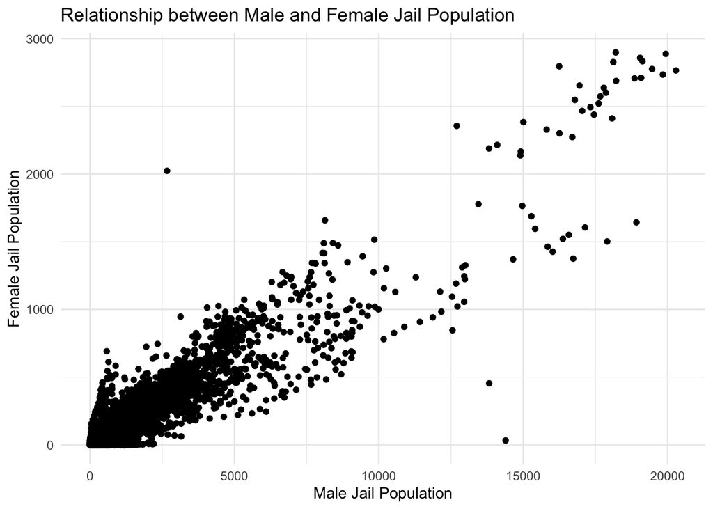

### Map

[output not shown]

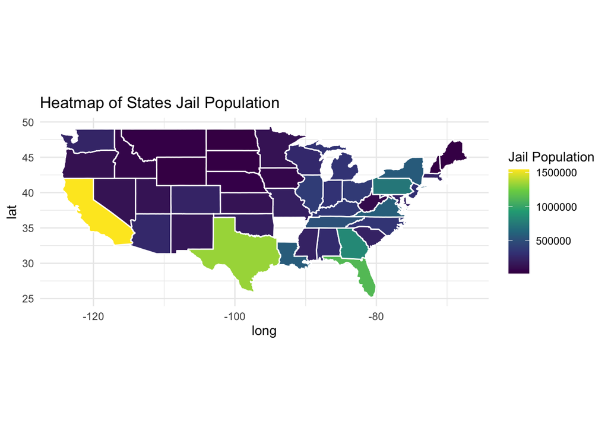